# Using Disease Modelling to Inform Mitigation Efforts

Allison K Shaw, Lauren A White, Matthew Michalska-Smith, Elizabeth T Borer, Meggan E Craft, Eric W Seabloom, Emilie Snell-Rood, & Michael Travisano

14 september 2020

## Problem | Balancing public health and university function

[figure not shown]

## Objectives | By the end of this lecture, you will be able to...

1. Describe how to approach answering research questions with models
2. Map mitigation/control measures onto model parameters
3. Discuss how underlying assumptions and methodological choices affect the conclusions that can be drawn from model results

## Case Study | [UMN EEB department returning to work](https://www.medrxiv.org/content/10.1101/2020.05.27.20114728v2.full)

## Case Study | Research questions

- How does returning to work affect the spread of disease
- What are the important variables that influence this spread
- How do we balance the inherent tradeoff between reducing COVID spread and the preserving economic activity
- Are there modifications to how we have worked in the past to better navigate this tradeoff?

### How to return to work safely?

## Models | Letting your questions dictate your model

## Models | Compartmental models

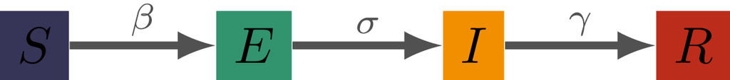

## Models | ODE SEIR

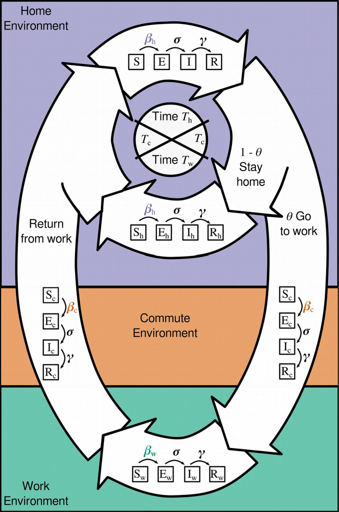

- tracks the proportion of the population in each class over time
- considers the spread of disease in different “environments”
- What are some of the limitations/assumptions you see in this model?

## Models | ODE SEIR

- Homogenous mixing
- Some parameters are the same in all environments
- Behavior doesn't change based on disease status
- *&c.*

## Models | Network chain binomial SEIR

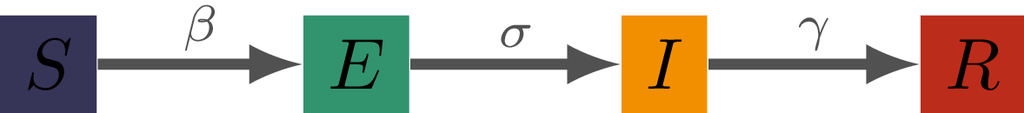

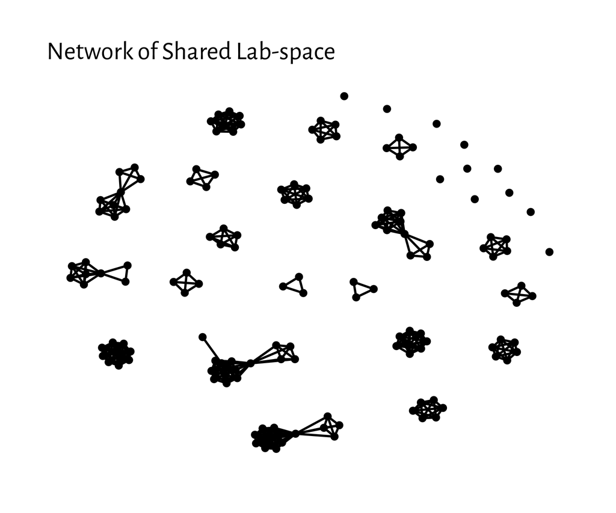

- Considers spatial configuration of people
- Allows exploration of the structure of interpersonal interactions
- What are some of the limitations of this way of representing the population?

## Models | Network chain binomial SEIR

- Doesn't contain common spaces
- All shared spaces are equivalent risk of transmission
- Network structure doesn't change based on disease status
- *&c.*

## Simulating Mitigation Efforts | Mapping interventions to parameters and *vice versa*

## Simulating Mitigation | ODE SEIR

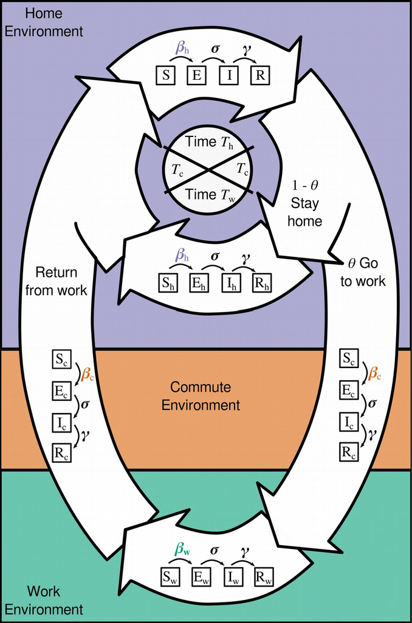

- Time at work/commute/home ($T_i$)
- Fraction of population working ($\theta$)
- Transmission rate(s) ($\beta_i$)
- Latent period, recovery rate ($\sigma$, $\gamma$)

## Simulating Mitigation | Network model

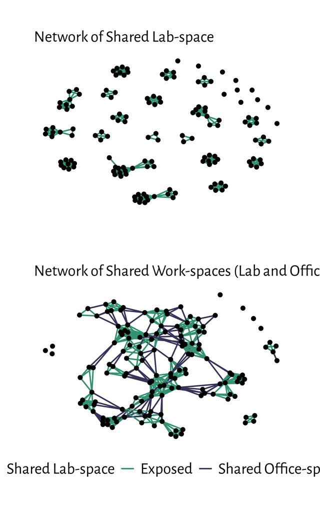

- Transmission rate(s) ($\beta_i$)
- Latent period, recovery rate ($\sigma$, $\gamma$)
- Limit types of work (change network structure)

## Drawing conclusions from models

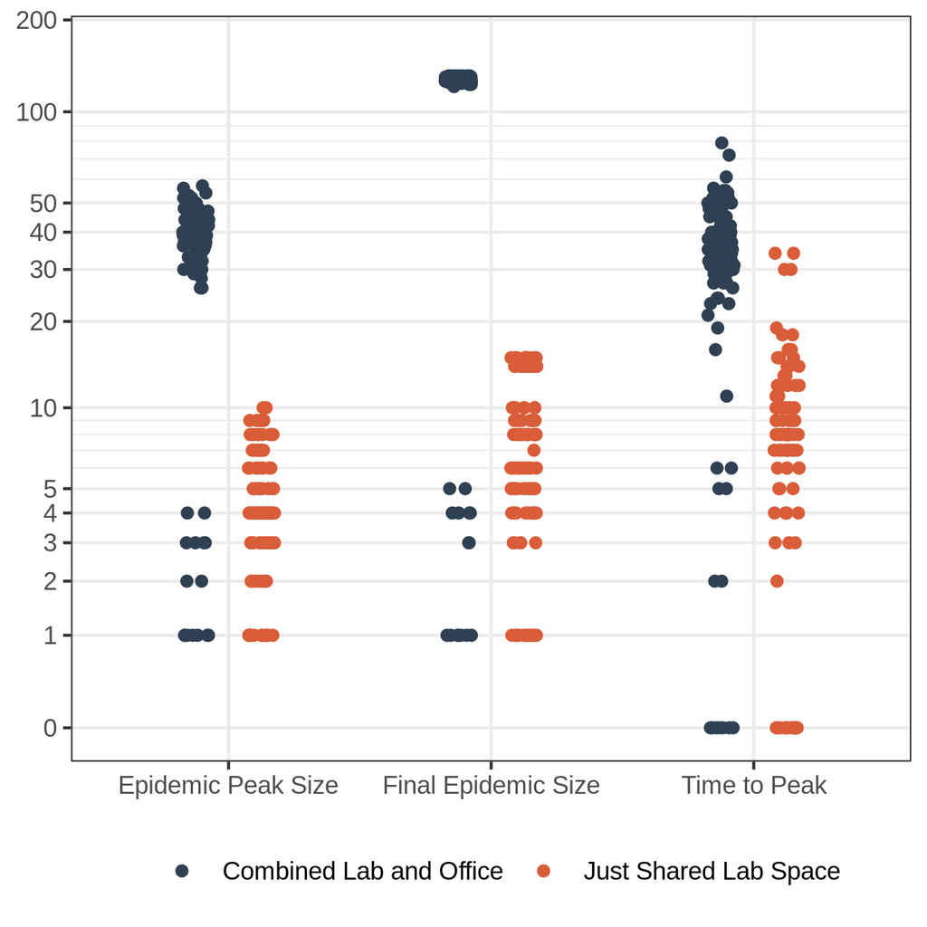

## [Now you try!](https://michalska-smith.shinyapps.io/UMN_EEB_SEIR/)

[interactive chart not shown]